# BÁO CÁO CHI TIẾT ODICH_TCM_YEAR_2026

Author

Hoang Quoc Cuong

Published

April 23, 2026

# **ODICH_TCM 2026**

Báo cáo được cập nhập vào lúc **2026-04-23 17:01:36 | Dữ liệu ODICH_TCM 2026**

Bản đồ Cần Thơ (thông tin chi tiết phường, xã mới) [**click here**](https://tuhocr.github.io/canthosxh/MAP_CANTHO)

**Để copy file ảnh đồ thị full-size, ta right-click lên hình, chọn `Open image in new tab`**

# 1 **KIỂM TRA DỮ LIỆU**

**Nhập dữ liệu sai lệch năm (vd: file 2025 nhưng lại có bệnh nhân của năm 2026)**

**`Dữ liệu nhập lệch năm`**

```
Dữ liệu ban đầu: 45
Dữ liệu sau khi lọc theo năm: 45
Dữ liệu nhập lệch năm: 0
```

**Nếu tổng số `TTYTKV` không vượt quá 22 (năm 2025) hay 20 (năm 2026) thì dữ liệu chính xác.**

**Tổng số TTYTKV là 16**

**`TTYTKV`**

```
    TTYT KV Bình Thủy TTYT KV Châu Thành HG   TTYT KV Cù Lao Dung       TTYT KV Kế Sách       TTYT KV Long Mỹ         TTYT KV Mỹ Tú
                    1                     3                     1                     3                     2                     2
     TTYT KV Mỹ Xuyên       TTYT KV Ngã Năm    TTYT KV Phụng Hiệp     TTYT KV Thạnh Trị      TTYT KV Thốt Nốt  TTYT KV TP Sóc Trăng
                    2                     2                     9                     2                     3                     6
      TTYT KV Trần Đề       TTYT KV Vị Thủy     TTYT KV Vĩnh Châu    TTYT KV Vĩnh Thạnh
                    2                     4                     2                     1
Tổng số TTYTKV là 16
```

**Nếu tổng số `PHUONG_XA_MOI` không vượt quá 103 thì dữ liệu chính xác.**

**Tổng số PHUONG_XA_MOI là 35**

**`PHUONG_XA_MOI`**

```
     Châu Thành     Cù Lao Dung      Đông Phước       Hiệp Hưng     Hồ Đắc Kiện          Hòa An       Khánh Hòa         Lâm Tân
              1               1               1               1               2               1               2               1
        Long Mỹ       Lương Tâm        Mỹ Hương         Mỹ Quới        Mỹ Xuyên         Ngã Bảy         Ngã Năm         Nhơn Mỹ
              1               1               2               1               1               2               1               1
        Nhu Gia       Ninh Kiều         Phú Hữu         Phú Lộc         Phú Tâm      Phụng Hiệp     Phương Bình         Tài Văn
              2               1               1               1               1               2               1               1
        Tân Lộc  Tân Phước Hưng       Thạnh Hòa      Thạnh Quới   Thạnh Thới An     Thới An Hội       Thuận Hòa      Trung Nhứt
              2               1               1               1               1               2               2               1
     Vị Thanh 1 Vĩnh Thuận Đông      Vĩnh Tường
              2               1               1
Tổng số PHUONG_XA_MOI là 35
```

**Nếu kết quả tổng số ca theo `TTYTKV` và `PHUONG_XA_MOI` không vượt quá 103 thì dữ liệu chính xác.**

Số liệu này thể hiện bao nhiều phường xã có ca bệnh tương ứng với trung tâm y tế khu vực, tổng số không vượt qua 103 phường xã. Cần kiểm tra xem 1 phường xã có bị trùng ở các trung tâm y tế khu vực khác nhau không.

**Dữ liệu bị trùng**

```
     Châu Thành     Cù Lao Dung      Đông Phước       Hiệp Hưng     Hồ Đắc Kiện          Hòa An       Khánh Hòa         Lâm Tân
              1               1               1               1               1               1               1               1
        Long Mỹ       Lương Tâm        Mỹ Hương         Mỹ Quới        Mỹ Xuyên         Ngã Bảy         Ngã Năm         Nhơn Mỹ
              1               1               1               1               1               1               1               1
        Nhu Gia       Ninh Kiều         Phú Hữu         Phú Lộc         Phú Tâm      Phụng Hiệp     Phương Bình         Tài Văn
              1               1               1               1               1               1               1               1
        Tân Lộc  Tân Phước Hưng       Thạnh Hòa      Thạnh Quới   Thạnh Thới An     Thới An Hội       Thuận Hòa      Trung Nhứt
              1               1               1               1               1               1               1               1
     Vị Thanh 1 Vĩnh Thuận Đông      Vĩnh Tường
              1               1               1
Tổng số PHUONG_XA_MOI là 35
[1] TTYTKV        PHUONG_XA_MOI TONG_SO_CA
<0 rows> (or 0-length row.names)
```

# 2 **SỐ** **Ổ DỊCH** **THEO NGÀY [DỮ LIỆU GỐC]**

[**Dữ liệu gốc ODICH_TCM_2026**](https://tuhocr.github.io/canthosxh/REPORT/ODICH_TCM_2026)

# 3 **TỔNG SỐ** **Ổ DỊCH** **TRONG NĂM THEO KHU VỰC**

**Từ ngày 2026-01-01 đến ngày 2026-04-11**

**Tổng số ổ dịch: 45 | Tổng số TTYT KV: 16 | Tổng số phường, xã: 103**

**Tổng số phường, xã có ổ dịch ODICH_TCM: 35**

**Tổng số phường, xã có KHÔNG có ODICH_TCM: 68 (An Bình, An Lạc Thôn, An Ninh, An Thạnh, Bình Thủy, Cái Khế, Cái Răng, Cờ Đỏ, Đại Hải, Đại Ngãi, Đại Thành, Đông Hiệp, Đông Thuận, Gia Hòa, Hỏa Lựu, Hòa Tú, Hưng Phú, Kế Sách, Lai Hòa, Lịch Hội Thượng, Liêu Tú, Long Bình, Long Hưng, Long Phú, Long Phú 1, Long Tuyền, Mỹ Phước, Mỹ Tú, Ngọc Tố, Nhơn Ái, Ô Môn, Phong Điền, Phong Nẫm, Phú Lợi, Phước Thới, Sóc Trăng, Tân An, Tân Bình, Tân Hòa, Tân Long, Tân Thạnh, Thạnh An, Thạnh Phú, Thạnh Xuân, Thới An Đông, Thới Hưng, Thới Lai, Thới Long, Thốt Nốt, Thuận Hưng, Trần Đề, Trung Hưng, Trường Khánh, Trường Long, Trường Long Tây, Trường Thành, Trường Xuân, Vị Tân, Vị Thanh, Vị Thủy, Vĩnh Châu, Vĩnh Hải, Vĩnh Lợi, Vĩnh Phước, Vĩnh Thạnh, Vĩnh Trinh, Vĩnh Viễn, Xà Phiên)**

| TTYTKV | Phường, xã mới | Tổng số ca |
| --- | --- | --- |
| TTYT KV Bình Thủy | Ninh Kiều | 1 |
| TTYT KV Châu Thành HG | Châu Thành | 1 |
| TTYT KV Châu Thành HG | Phú Hữu | 1 |
| TTYT KV Châu Thành HG | Đông Phước | 1 |
| TTYT KV Cù Lao Dung | Cù Lao Dung | 1 |
| TTYT KV Kế Sách | Thới An Hội | 2 |
| TTYT KV Kế Sách | Nhơn Mỹ | 1 |
| TTYT KV Long Mỹ | Long Mỹ | 1 |
| TTYT KV Long Mỹ | Lương Tâm | 1 |
| TTYT KV Mỹ Tú | Mỹ Hương | 2 |

[output cut: 25 more lines]

# 4 **ĐỒ THỊ TỔNG SỐ** **Ổ DỊCH** **THEO KHU VỰC**

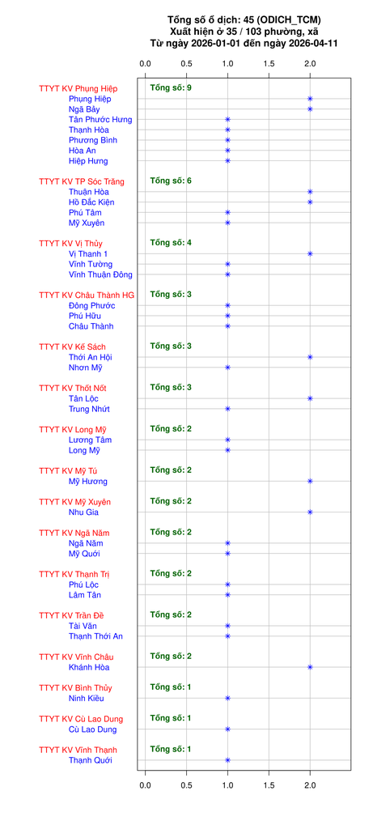

# 5 **TỔNG SỐ** **Ổ DỊCH** **THEO THÁNG**

| TTYTKV | Phường, xã mới | Tháng | Tổng số ca |
| --- | --- | --- | --- |
| TTYT KV Phụng Hiệp | Hiệp Hưng | 1 | 1 |
| TTYT KV Mỹ Tú | Mỹ Hương | 1 | 1 |
| TTYT KV Kế Sách | Nhơn Mỹ | 1 | 1 |
| TTYT KV Mỹ Xuyên | Nhu Gia | 1 | 1 |
| TTYT KV Phụng Hiệp | Tân Phước Hưng | 1 | 1 |
| TTYT KV Phụng Hiệp | Thạnh Hòa | 1 | 1 |
| TTYT KV Kế Sách | Thới An Hội | 1 | 1 |
| TTYT KV Châu Thành HG | Đông Phước | 2 | 1 |
| TTYT KV Vĩnh Châu | Khánh Hòa | 2 | 1 |
| TTYT KV TP Sóc Trăng | Mỹ Xuyên | 2 | 1 |

[output cut: 32 more lines]

# 6 **ĐỒ THỊ TỔNG SỐ** **Ổ DỊCH** **THEO THỜI GIAN**

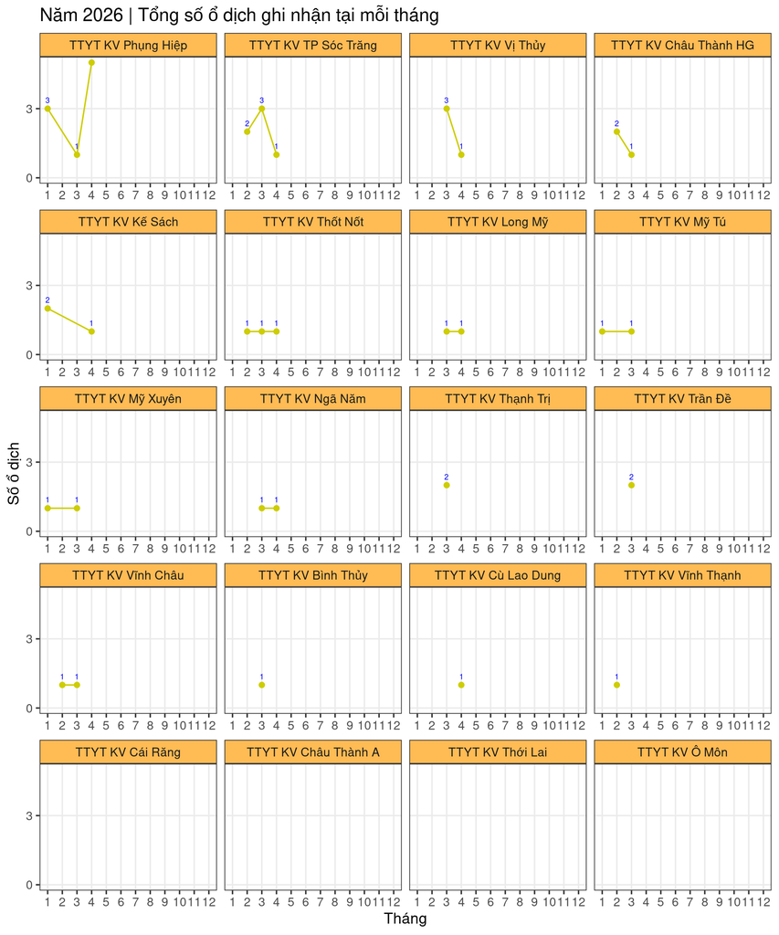

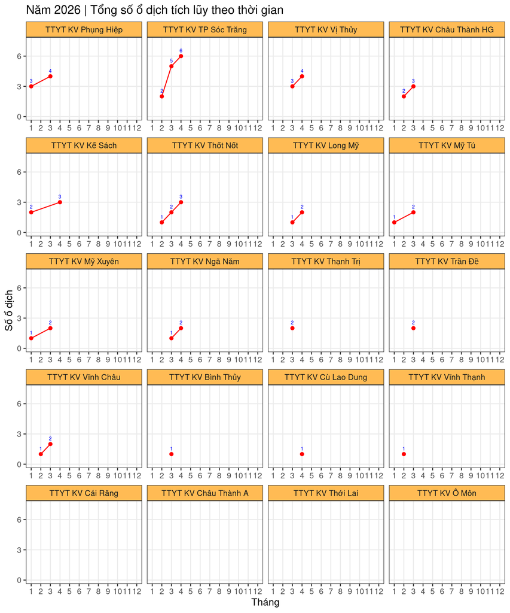

# 7 **TỔNG SỐ** **Ổ DỊCH** **THEO TUẦN**

| TTYTKV | PHUONG_XA_MOI | WEEK | COUNT |
| --- | --- | --- | --- |
| TTYT KV Phụng Hiệp | Hiệp Hưng | 1 | 1 |
| TTYT KV Mỹ Tú | Mỹ Hương | 1 | 1 |
| TTYT KV Mỹ Xuyên | Nhu Gia | 1 | 1 |
| TTYT KV Phụng Hiệp | Tân Phước Hưng | 2 | 1 |
| TTYT KV Phụng Hiệp | Thạnh Hòa | 2 | 1 |
| TTYT KV Kế Sách | Thới An Hội | 3 | 1 |
| TTYT KV Kế Sách | Nhơn Mỹ | 4 | 1 |
| TTYT KV Châu Thành HG | Đông Phước | 5 | 1 |
| TTYT KV Vĩnh Thạnh | Thạnh Quới | 6 | 1 |
| TTYT KV TP Sóc Trăng | Mỹ Xuyên | 8 | 1 |

[output cut: 33 more lines]

# 8 **ĐỒ THỊ THEO NGÀY**

## 8.1 TTYT KV Phụng Hiệp

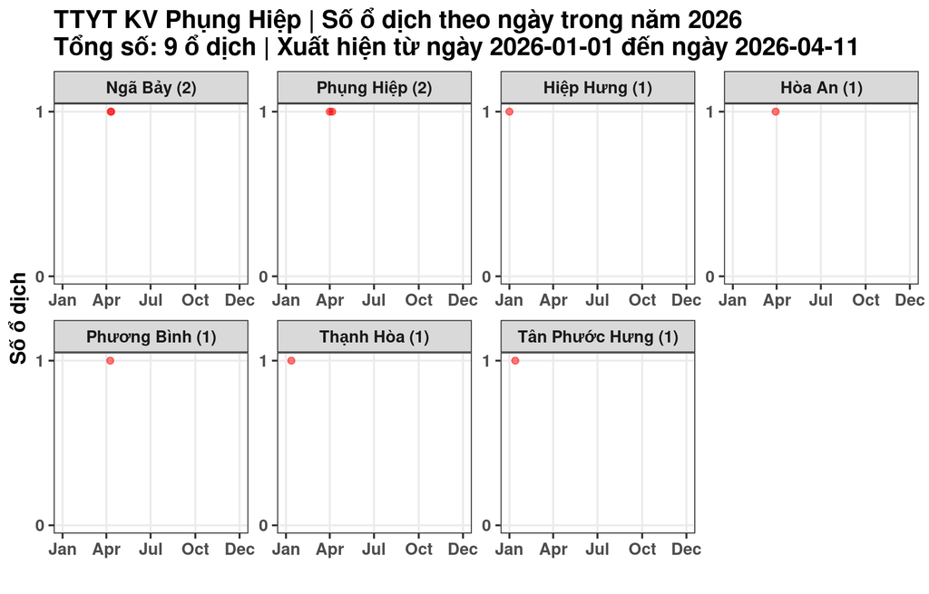

## 8.2 TTYT KV Mỹ Xuyên

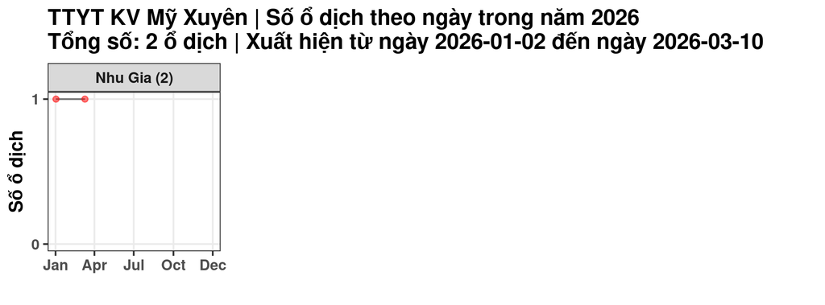

## 8.3 TTYT KV Mỹ Tú

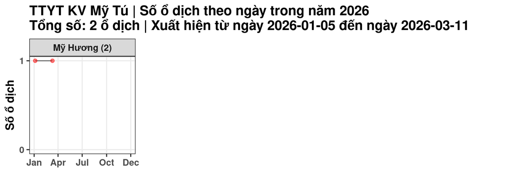

## 8.4 TTYT KV Kế Sách

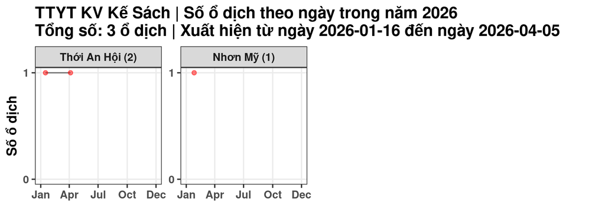

## 8.5 TTYT KV Châu Thành HG

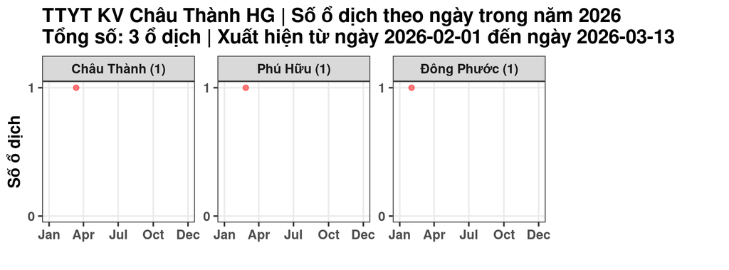

## 8.6 TTYT KV Vĩnh Thạnh

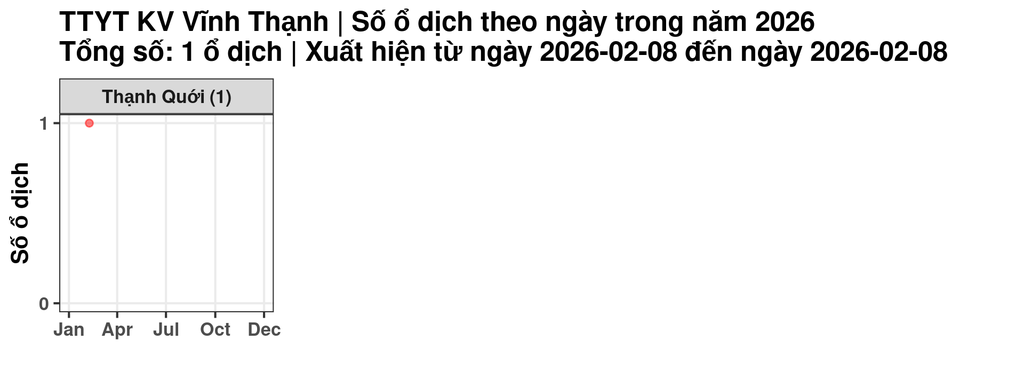

## 8.7 TTYT KV TP Sóc Trăng

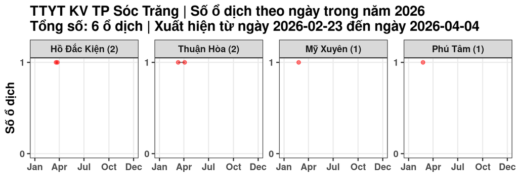

## 8.8 TTYT KV Vĩnh Châu

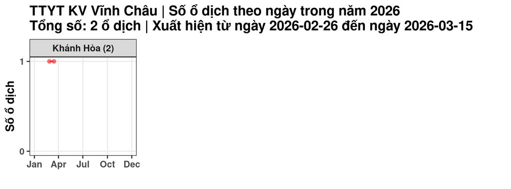

## 8.9 TTYT KV Thốt Nốt

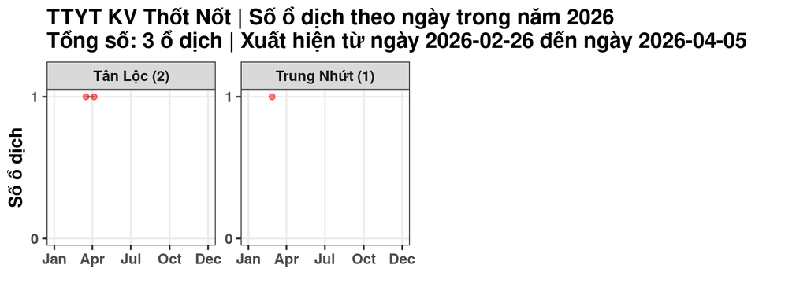

## 8.10 TTYT KV Thạnh Trị

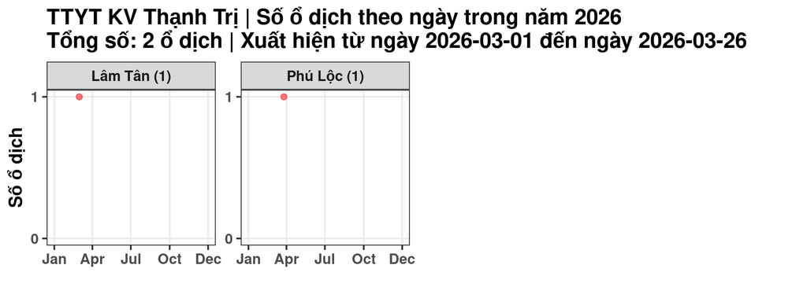

## 8.11 TTYT KV Trần Đề

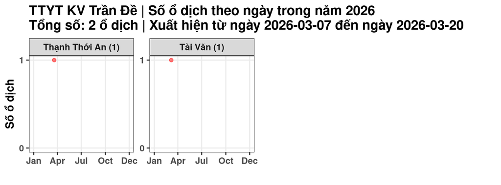

## 8.12 TTYT KV Ngã Năm

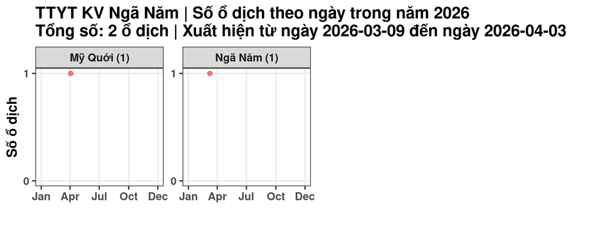

## 8.13 TTYT KV Vị Thủy

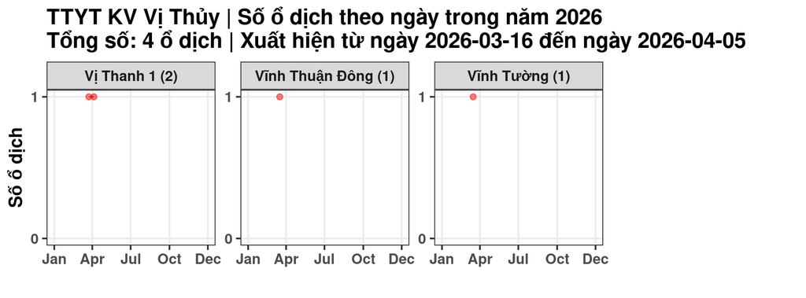

## 8.14 TTYT KV Long Mỹ

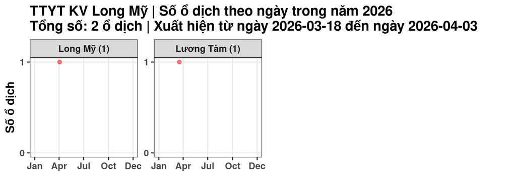

## 8.15 TTYT KV Bình Thủy

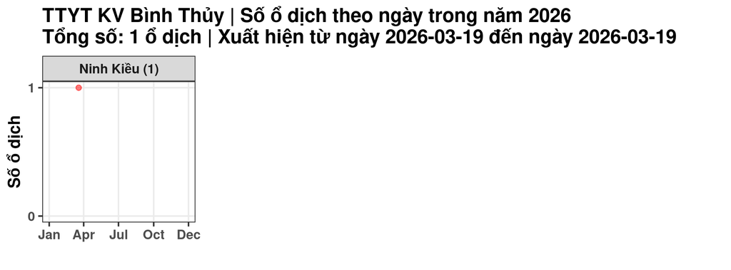

## 8.16 TTYT KV Cù Lao Dung

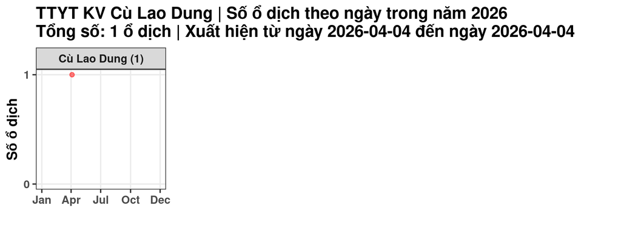

# 9 **ĐỒ THỊ THEO TUẦN**

## 9.1 TTYT KV Phụng Hiệp

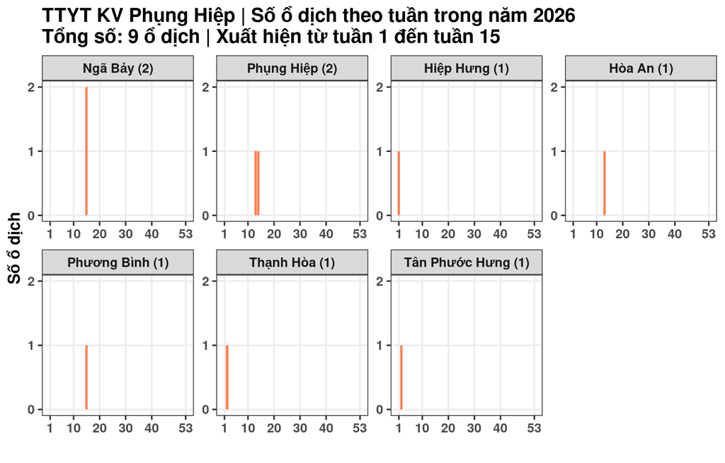

## 9.2 TTYT KV Mỹ Tú

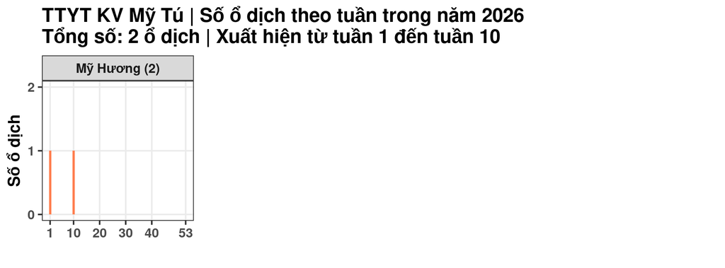

## 9.3 TTYT KV Mỹ Xuyên

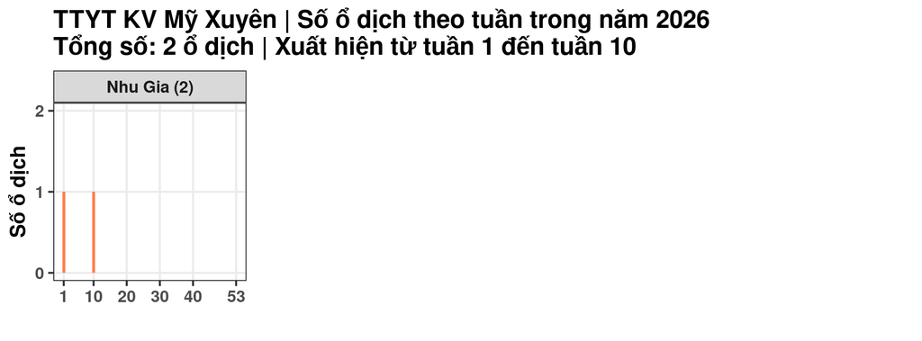

## 9.4 TTYT KV Kế Sách

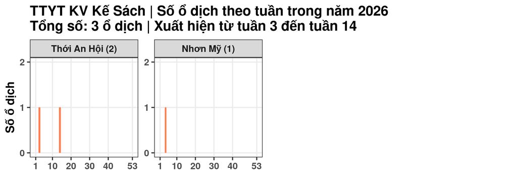

## 9.5 TTYT KV Châu Thành HG

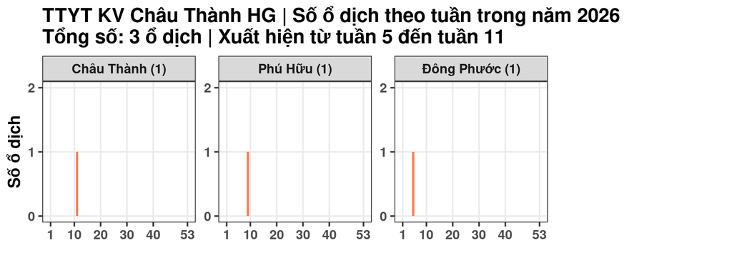

## 9.6 TTYT KV Vĩnh Thạnh

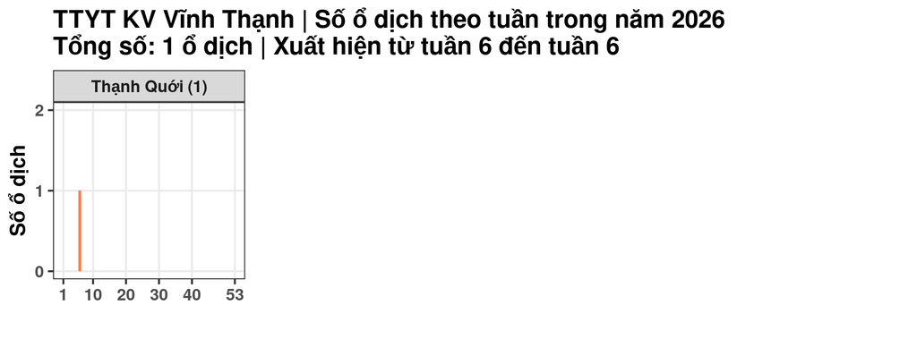

## 9.7 TTYT KV TP Sóc Trăng

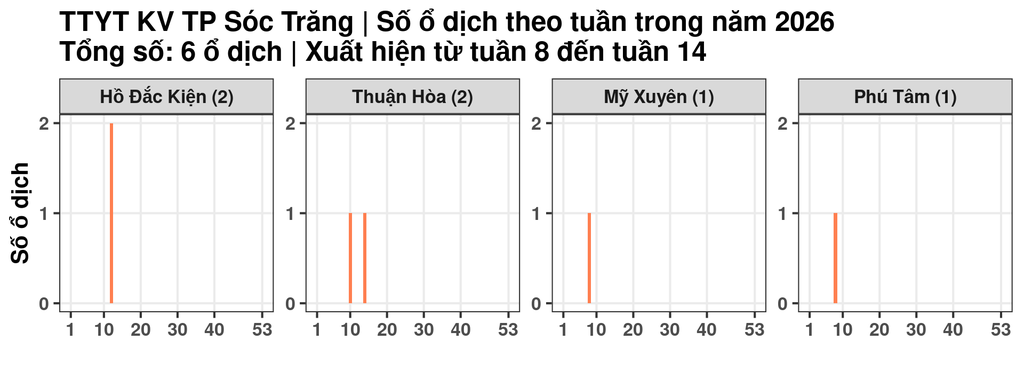

## 9.8 TTYT KV Vĩnh Châu

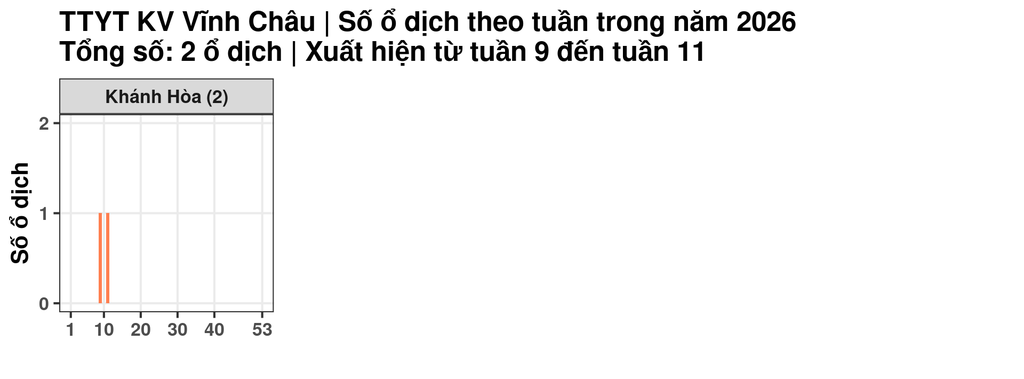

## 9.9 TTYT KV Thạnh Trị

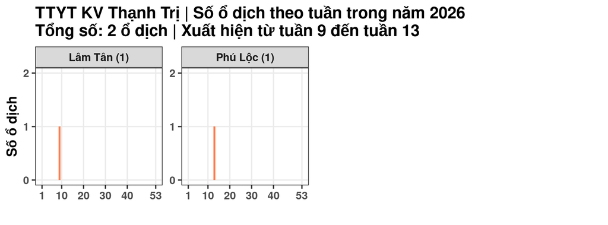

## 9.10 TTYT KV Thốt Nốt

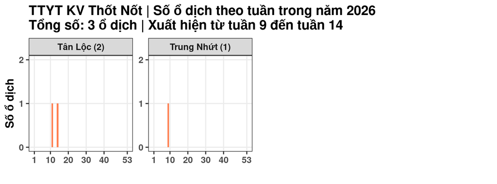

## 9.11 TTYT KV Ngã Năm

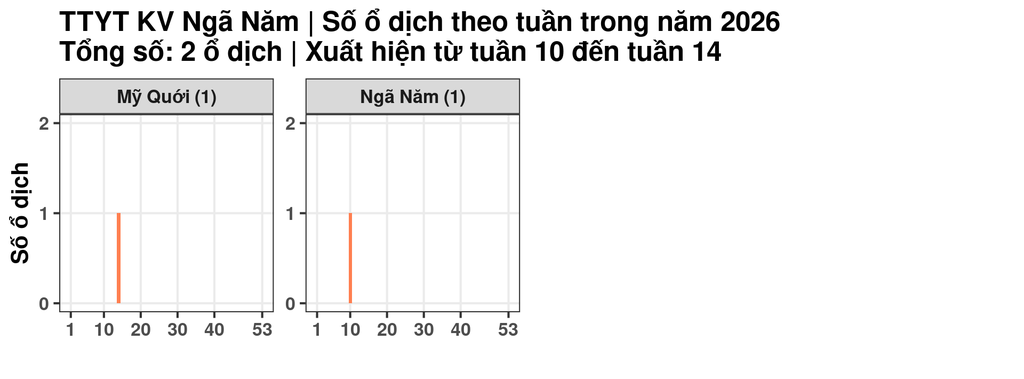

## 9.12 TTYT KV Trần Đề

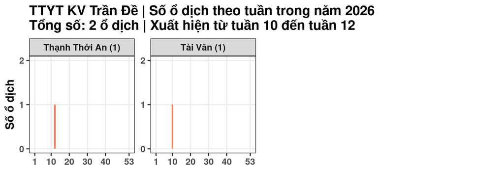